# Final Project

Claudia Lo

2022-05-13

## Predicting Diabetes Readmission

This diabetes dataset from https://archive.ics.uci.edu/ml/datasets/diabetes+130-us+hospitals+for+years+1999-2008 is a record of 10 years(1999-2008) of clinical care at 130 US hospitals. Through my study, I will explore which features have a high chance of affecting readmission and predict the probability of patient readmission.

```r
#set working directory
getwd()
```

```
## [1] "C:/Users/claud/OneDrive/Desktop/spr 2022/HS 614 data analytics/final project"
```

```r
setwd("C:/Users/claud/OneDrive/Desktop/spr 2022/HS 614 data analytics/final project")
```

```r
#Import datasets
readmission<-read.csv("./data/diabetic_data.csv",na.string="?",header = TRUE, sep = ",")
```

```r
readmission_id<-read.csv("./data/IDs_mapping.csv",na.string="?",header = TRUE, sep = ",")
readmission_id
```

```
##           admission_type_id
## 1                         1
## 2                         2
## 3                         3
## 4                         4
## 5                         5
## 6                         6
## 7                         7
## 8                         8
## 9
## 10 discharge_disposition_id
## 11                        1
## 12                        2
## 13                        3
## 14                        4
```

[output cut: 121 more lines]

```r
head(readmission)
```

```
##   encounter_id patient_nbr            race gender     age weight
## 1      2278392     8222157       Caucasian Female  [0-10)   <NA>
## 2       149190    55629189       Caucasian Female [10-20)   <NA>
## 3        64410    86047875 AfricanAmerican Female [20-30)   <NA>
## 4       500364    82442376       Caucasian   Male [30-40)   <NA>
## 5        16680    42519267       Caucasian   Male [40-50)   <NA>
## 6        35754    82637451       Caucasian   Male [50-60)   <NA>
##   admission_type_id discharge_disposition_id admission_source_id
## 1                 6                       25                   1
## 2                 1                        1                   7
## 3                 1                        1                   7
## 4                 1                        1                   7
## 5                 1                        1                   7
## 6                 2                        1                   2
##   time_in_hospital payer_code        medical_specialty num_lab_procedures
```

[output cut: 55 more lines]

```r
str(readmission)
```

```
## 'data.frame':    101766 obs. of  50 variables:
##  $ encounter_id            : int  2278392 149190 64410 500364 16680 35754 55842 63768 12522 15738 ...
##  $ patient_nbr             : int  8222157 55629189 86047875 82442376 42519267 82637451 84259809 114882984 48330783 63555939 ...
##  $ race                    : chr  "Caucasian" "Caucasian" "AfricanAmerican" "Caucasian" ...
##  $ gender                  : chr  "Female" "Female" "Female" "Male" ...
##  $ age                     : chr  "[0-10)" "[10-20)" "[20-30)" "[30-40)" ...
##  $ weight                  : chr  NA NA NA NA ...
##  $ admission_type_id       : int  6 1 1 1 1 2 3 1 2 3 ...
##  $ discharge_disposition_id: int  25 1 1 1 1 1 1 1 1 3 ...
##  $ admission_source_id     : int  1 7 7 7 7 2 2 7 4 4 ...
##  $ time_in_hospital        : int  1 3 2 2 1 3 4 5 13 12 ...
##  $ payer_code              : chr  NA NA NA NA ...
##  $ medical_specialty       : chr  "Pediatrics-Endocrinology" NA NA NA ...
##  $ num_lab_procedures      : int  41 59 11 44 51 31 70 73 68 33 ...
##  $ num_procedures          : int  0 0 5 1 0 6 1 0 2 3 ...
```

[output cut: 36 more lines]

```r
summary(readmission)
```

```
##   encounter_id        patient_nbr            race              gender
##  Min.   :    12522   Min.   :      135   Length:101766      Length:101766
##  1st Qu.: 84961194   1st Qu.: 23413221   Class :character   Class :character
##  Median :152388987   Median : 45505143   Mode  :character   Mode  :character
##  Mean   :165201646   Mean   : 54330401
##  3rd Qu.:230270888   3rd Qu.: 87545950
##  Max.   :443867222   Max.   :189502619
##      age               weight          admission_type_id
##  Length:101766      Length:101766      Min.   :1.000
##  Class :character   Class :character   1st Qu.:1.000
##  Mode  :character   Mode  :character   Median :1.000
##                                        Mean   :2.024
##                                        3rd Qu.:3.000
##                                        Max.   :8.000
##  discharge_disposition_id admission_source_id time_in_hospital
##  Min.   : 1.000           Min.   : 1.000      Min.   : 1.000
##  1st Qu.: 1.000           1st Qu.: 1.000      1st Qu.: 2.000
##  Median : 1.000           Median : 7.000      Median : 4.000
##  Mean   : 3.716           Mean   : 5.754      Mean   : 4.396
##  3rd Qu.: 4.000           3rd Qu.: 7.000      3rd Qu.: 6.000
##  Max.   :28.000           Max.   :25.000      Max.   :14.000
##   payer_code        medical_specialty  num_lab_procedures num_procedures
##  Length:101766      Length:101766      Min.   :  1.0      Min.   :0.00
##  Class :character   Class :character   1st Qu.: 31.0      1st Qu.:0.00
##  Mode  :character   Mode  :character   Median : 44.0      Median :1.00
##                                        Mean   : 43.1      Mean   :1.34
##                                        3rd Qu.: 57.0      3rd Qu.:2.00
##                                        Max.   :132.0      Max.   :6.00
##  num_medications number_outpatient number_emergency  number_inpatient
##  Min.   : 1.00   Min.   : 0.0000   Min.   : 0.0000   Min.   : 0.0000
##  1st Qu.:10.00   1st Qu.: 0.0000   1st Qu.: 0.0000   1st Qu.: 0.0000
##  Median :15.00   Median : 0.0000   Median : 0.0000   Median : 0.0000
##  Mean   :16.02   Mean   : 0.3694   Mean   : 0.1978   Mean   : 0.6356
##  3rd Qu.:20.00   3rd Qu.: 0.0000   3rd Qu.: 0.0000   3rd Qu.: 1.0000
##  Max.   :81.00   Max.   :42.0000   Max.   :76.0000   Max.   :21.0000
##     diag_1             diag_2             diag_3          number_diagnoses
##  Length:101766      Length:101766      Length:101766      Min.   : 1.000
##  Class :character   Class :character   Class :character   1st Qu.: 6.000
##  Mode  :character   Mode  :character   Mode  :character   Median : 8.000
##                                                           Mean   : 7.423
```

[output cut: 43 more lines]

```
##
##  metformin.rosiglitazone metformin.pioglitazone    change
##  Length:101766           Length:101766          Length:101766
##  Class :character        Class :character       Class :character
##  Mode  :character        Mode  :character       Mode  :character
##
##
##
##  diabetesMed         readmitted
##  Length:101766      Length:101766
##  Class :character   Class :character
##  Mode  :character   Mode  :character
##
##
##
```

```r
nrow(readmission)
```

```
## [1] 101766
```

```r
ncol(readmission)
```

```
## [1] 50
```

```r
#count number of missing values
colSums(is.na(readmission))
```

```
##             encounter_id              patient_nbr                     race
##                        0                        0                     2273
##                   gender                      age                   weight
##                        0                        0                    98569
##        admission_type_id discharge_disposition_id      admission_source_id
##                        0                        0                        0
##         time_in_hospital               payer_code        medical_specialty
##                        0                    40256                    49949
##       num_lab_procedures           num_procedures          num_medications
##                        0                        0                        0
##        number_outpatient         number_emergency         number_inpatient
##                        0                        0                        0
##                   diag_1                   diag_2                   diag_3
##                       21                      358                     1423
##         number_diagnoses            max_glu_serum                A1Cresult
##                        0                        0                        0
##                metformin              repaglinide              nateglinide
##                        0                        0                        0
##           chlorpropamide              glimepiride            acetohexamide
##                        0                        0                        0
##                glipizide                glyburide              tolbutamide
##                        0                        0                        0
##             pioglitazone            rosiglitazone                 acarbose
##                        0                        0                        0
##                 miglitol             troglitazone               tolazamide
##                        0                        0                        0
##                  examide              citoglipton                  insulin
##                        0                        0                        0
##      glyburide.metformin      glipizide.metformin glimepiride.pioglitazone
##                        0                        0                        0
##  metformin.rosiglitazone   metformin.pioglitazone                   change
##                        0                        0                        0
##              diabetesMed               readmitted
##                        0                        0
```

```r
#change chr variables to factor
readmission[sapply(readmission, is.character)] <- lapply(readmission[sapply(readmission, is.character)],as.factor)
```

```r
str(readmission)
```

```
## 'data.frame':    101766 obs. of  50 variables:
##  $ encounter_id            : int  2278392 149190 64410 500364 16680 35754 55842 63768 12522 15738 ...
##  $ patient_nbr             : int  8222157 55629189 86047875 82442376 42519267 82637451 84259809 114882984 48330783 63555939 ...
##  $ race                    : Factor w/ 5 levels "AfricanAmerican",..: 3 3 1 3 3 3 3 3 3 3 ...
##  $ gender                  : Factor w/ 3 levels "Female","Male",..: 1 1 1 2 2 2 2 2 1 1 ...
##  $ age                     : Factor w/ 10 levels "[0-10)","[10-20)",..: 1 2 3 4 5 6 7 8 9 10 ...
##  $ weight                  : Factor w/ 9 levels "[0-25)","[100-125)",..: NA NA NA NA NA NA NA NA NA NA ...
##  $ admission_type_id       : int  6 1 1 1 1 2 3 1 2 3 ...
##  $ discharge_disposition_id: int  25 1 1 1 1 1 1 1 1 3 ...
##  $ admission_source_id     : int  1 7 7 7 7 2 2 7 4 4 ...
##  $ time_in_hospital        : int  1 3 2 2 1 3 4 5 13 12 ...
##  $ payer_code              : Factor w/ 17 levels "BC","CH","CM",..: NA NA NA NA NA NA NA NA NA NA ...
##  $ medical_specialty       : Factor w/ 72 levels "AllergyandImmunology",..: 38 NA NA NA NA NA NA NA NA 19 ...
##  $ num_lab_procedures      : int  41 59 11 44 51 31 70 73 68 33 ...
##  $ num_procedures          : int  0 0 5 1 0 6 1 0 2 3 ...
```

[output cut: 36 more lines]

##Cleaning data

```r
#removing columns that are not useful and have a lot of missing values
readmission <- readmission[, -c(1, 2, 6,11,12)]
```

```r
nrow(readmission)
```

```
## [1] 101766
```

```r
ncol(readmission)
```

```
## [1] 45
```

```r
table(readmission$max_glu_serum)
```

```
##
##  >200  >300  None  Norm
##  1485  1264 96420  2597
```

```r
table(readmission$A1Cresult)
```

```
##
##    >7    >8  None  Norm
##  3812  8216 84748  4990
```

```r
readmission <- readmission[!readmission$max_glu_serum == "None", ]
readmission <- readmission[!readmission$A1Cresult == "None", ]
```

```r
nrow(readmission)
```

```
## [1] 298
```

```r
table(readmission$max_glu_serum)
```

```
##
## >200 >300 None Norm
##   71  129    0   98
```

```r
table(readmission$A1Cresult)
```

```
##
##   >7   >8 None Norm
##   63  177    0   58
```

```r
nrow(readmission)
```

```
## [1] 298
```

```r
ncol(readmission)
```

```
## [1] 45
```

##Classifying outcome variable into two groups

```r
table(readmission$readmitted)
```

```
##
## <30 >30  NO
##  36 139 123
```

```r
#binary responses function
binary = function(x){
    if(x == '<30'| x == '>30'){
        return('YES')
    }else{ return('NO')}
}
```

```r
binary('<30')
```

```
## [1] "YES"
```

```r
binary('>30')
```

```
## [1] "YES"
```

```r
binary('NO')
```

```
## [1] "NO"
```

```r
readmission$readmitted <- sapply(readmission[,c('readmitted')], function(x) binary(x))
```

```r
table(readmission$readmitted)
```

```
##
##  NO YES
## 123 175
```

##EDA

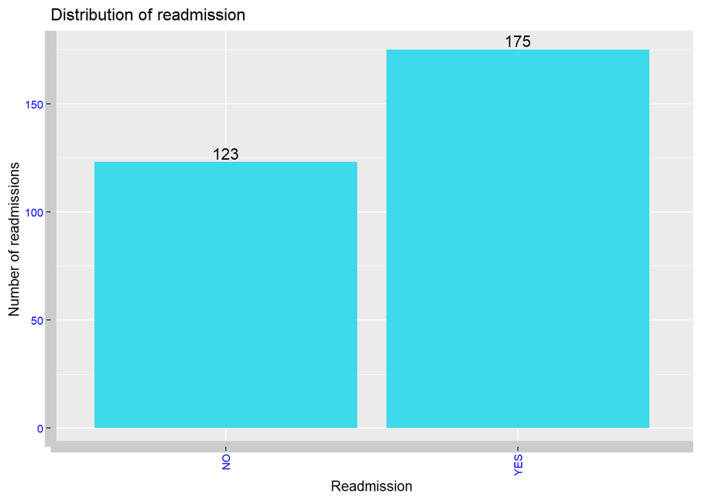

```r
#barplot of outcome variable
library(dplyr)
library(ggplot2)
df <- readmission %>%
          filter(!is.na(readmitted)) %>%
          group_by(readmitted) %>%
  summarise(count_m= n())
        p <-ggplot(df, aes(x = readmitted, y = count_m)) +
          geom_bar(fill = "#3DDAEB", stat = "identity") +
          geom_text(aes(label = count_m), vjust = -0.25,size = 4) +
          theme(axis.text = element_text(colour = "blue"),text = element_text(size=10),axis.line = element_line(size = 4, colour = "grey80"),axis.text.x = element_text(angle = 90, vjust = 0.45, hjust=1)) + ylab("Number of readmissions") + xlab("Readmission") + ggtitle(labs(title = "Distribution of readmission"))
p
```

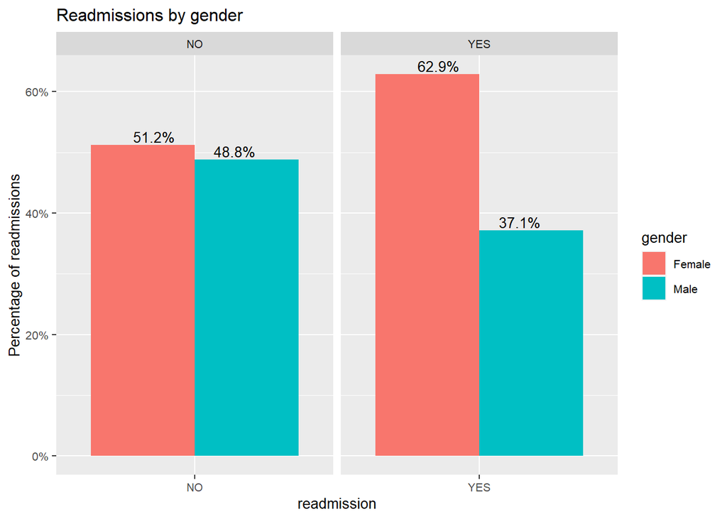

```r
#grouped barplot of gender and readmission
d4 <- readmission %>%
  group_by(readmitted,gender) %>%
  summarise(count=n()) %>%
  mutate(perc=count/sum(count))
bar4 <- ggplot(data=d4, aes(x=readmitted, y=perc, fill=gender)) +
  geom_bar(position = 'dodge', stat ='identity')+scale_y_continuous(labels = scales::percent)+labs(x = "readmission", y = "Percentage of readmissions", fill = "gender") + ggtitle(labs(title = "Readmissions by gender"))+ theme(text = element_text(size=10))+ geom_text(aes(label = scales::percent(perc),y = perc),position=position_dodge(width=0.7), vjust = -0.25,size=3.5)
bar4  + facet_grid(. ~ readmitted,scales='free')
```

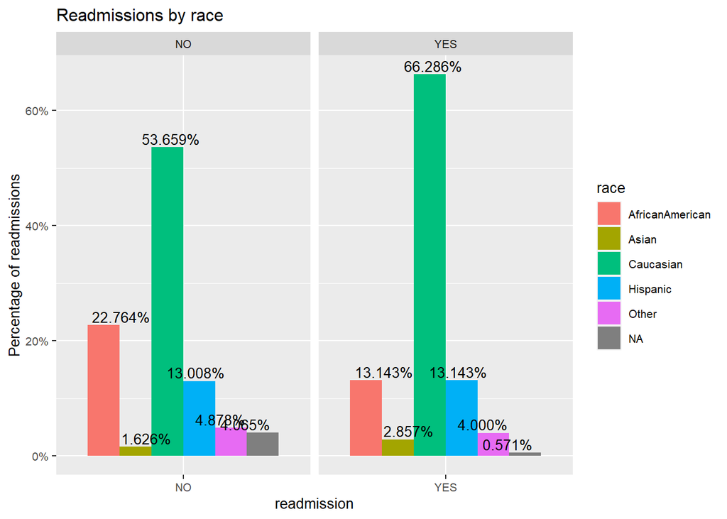

```r
#grouped barplot of race and readmission
d5 <- readmission %>%
  group_by(readmitted,race) %>%
  summarise(count=n()) %>%
  mutate(perc=count/sum(count))
bar4 <- ggplot(data=d5, aes(x=readmitted, y=perc, fill=race)) +
  geom_bar(position = 'dodge', stat ='identity')+scale_y_continuous(labels = scales::percent)+labs(x = "readmission", y = "Percentage of readmissions", fill = "race") + ggtitle(labs(title = "Readmissions by race"))+ theme(text = element_text(size=10))+ geom_text(aes(label = scales::percent(perc),y = perc),position=position_dodge(width=0.7), vjust = -0.25,size=3.5)
bar4  + facet_grid(. ~ readmitted,scales='free')
```

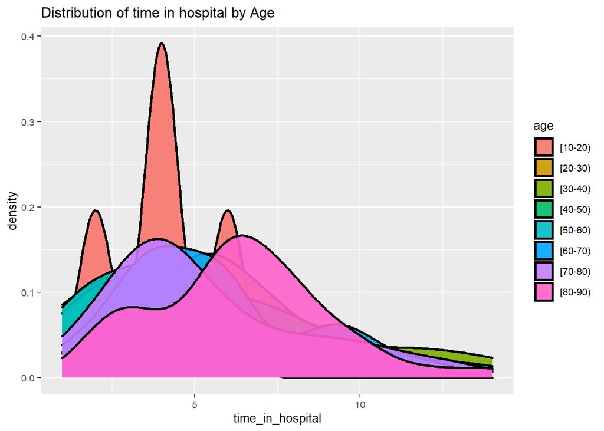

```r
#density plot of time in hospital and age
Densityplot <- ggplot(data = readmission,aes(x=time_in_hospital,fill= age ))+ geom_density(alpha = 0.9,cex=1)+ggtitle(labs(title = "Distribution of time in hospital by Age"))+theme(text = element_text(size=10))
Densityplot
```

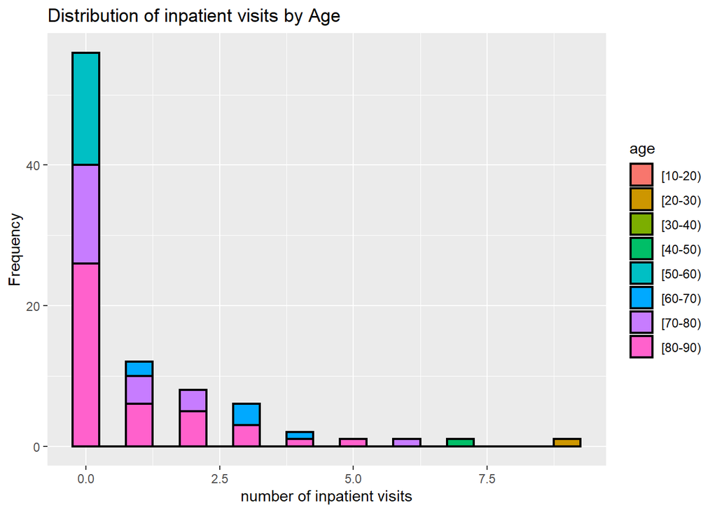

```r
#grouped histogram of number of inpatient visits and age
ggplot(readmission, aes(x = number_inpatient, fill = age)) + geom_histogram(colour = "black",binwidth = .5, lwd = .75, linetype= 1,position = "identity", alpha = 4) + labs(x = "number of inpatient visits", y = "Frequency", title = "Distribution of inpatient visits by Age")
```

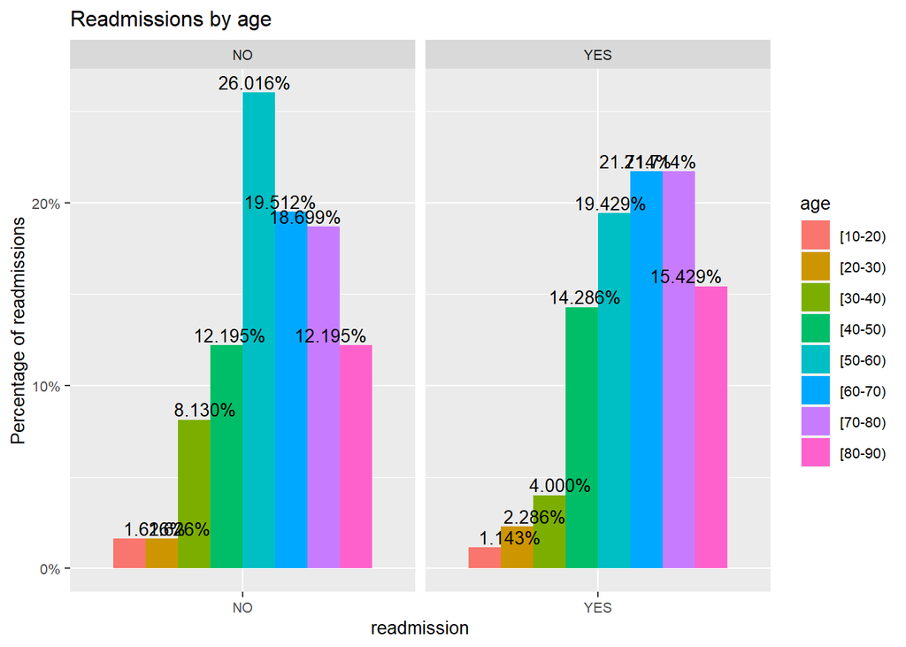

```r
#grouped barplot of age and readmission
d6 <- readmission %>%
  group_by(readmitted,age) %>%
  summarise(count=n()) %>%
  mutate(perc=count/sum(count))
bar4 <- ggplot(data=d6, aes(x=readmitted, y=perc, fill=age)) +
  geom_bar(position = 'dodge', stat ='identity')+scale_y_continuous(labels = scales::percent)+labs(x = "readmission", y = "Percentage of readmissions", fill = "age") + ggtitle(labs(title = "Readmissions by age"))+ theme(text = element_text(size=10))+ geom_text(aes(label = scales::percent(perc),y = perc),position=position_dodge(width=0.7), vjust = -0.25,size=3.5)
bar4  + facet_grid(. ~ readmitted,scales='free')
```

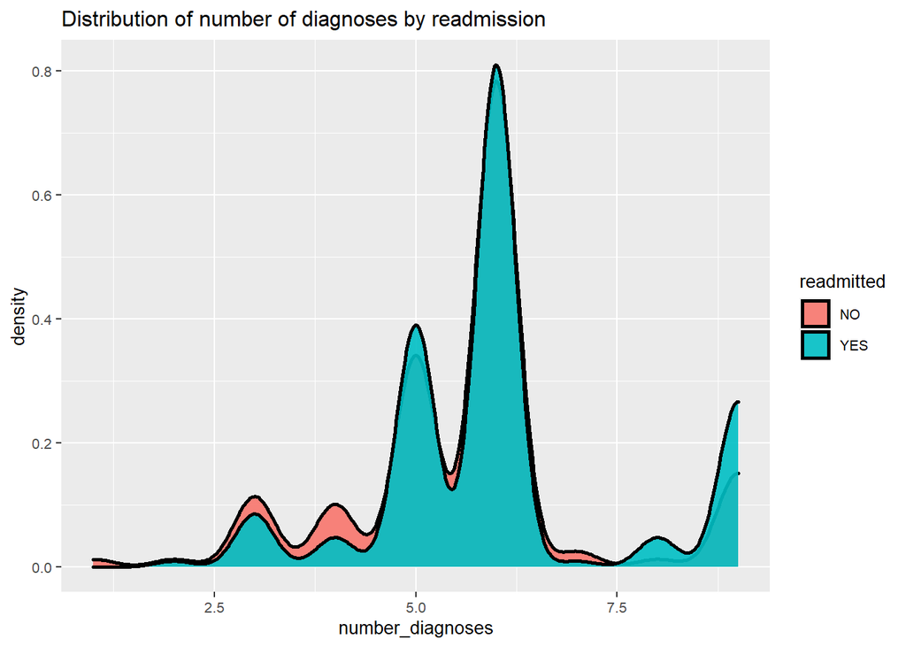

```r
#density plot of number of diagnoses and readmission
Densityplot <- ggplot(data = readmission,aes(x=number_diagnoses,fill= readmitted ))+ geom_density(alpha = 0.9,cex=1)+ggtitle(labs(title = "Distribution of number of diagnoses by readmission"))+theme(text = element_text(size=10))
Densityplot
```

```r
class(readmission$discharge_disposition_id)
```

```
## [1] "integer"
```

```r
class(readmission$admission_type_id)
```

```
## [1] "integer"
```

```r
class(readmission$admission_source_id)
```

```
## [1] "integer"
```

```r
readmission$discharge_disposition_id <- as.factor(readmission$discharge_disposition_id)
readmission$admission_type_id <- as.factor(readmission$admission_type_id)
readmission$admission_source_id <- as.factor(readmission$admission_source_id)
```

```r
str(readmission)
```

```
## 'data.frame':    298 obs. of  45 variables:
##  $ race                    : Factor w/ 5 levels "AfricanAmerican",..: 3 3 1 3 5 3 3 4 3 3 ...
##  $ gender                  : Factor w/ 3 levels "Female","Male",..: 2 1 1 1 2 1 2 1 1 1 ...
##  $ age                     : Factor w/ 10 levels "[0-10)","[10-20)",..: 9 5 8 6 8 4 9 6 5 6 ...
##  $ admission_type_id       : Factor w/ 4 levels "1","2","3","6": 4 4 4 4 4 4 4 4 4 4 ...
##  $ discharge_disposition_id: Factor w/ 9 levels "1","2","3","5",..: 3 1 1 1 5 1 1 1 1 1 ...
##  $ admission_source_id     : Factor w/ 3 levels "1","2","7": 3 3 3 3 3 2 3 3 3 3 ...
##  $ time_in_hospital        : int  5 2 10 2 11 14 7 2 3 2 ...
##  $ num_lab_procedures      : int  47 53 72 61 71 43 105 66 76 43 ...
##  $ num_procedures          : int  1 0 1 0 1 0 3 0 0 0 ...
##  $ num_medications         : int  6 4 19 5 20 11 16 3 9 13 ...
##  $ number_outpatient       : int  0 0 0 0 0 0 0 0 0 0 ...
##  $ number_emergency        : int  0 0 0 0 0 0 0 0 0 0 ...
##  $ number_inpatient        : int  0 0 0 0 0 0 0 0 0 0 ...
##  $ diag_1                  : Factor w/ 716 levels "10","11","110",..: 191 98 98 144 573 164 277 99 163 476 ...
```

[output cut: 31 more lines]

```r
#dataset with numeric variables
library(dplyr)
readmission_num<-select_if(readmission,is.numeric)
readmission_num
```

```
##        time_in_hospital num_lab_procedures num_procedures num_medications
## 163                   5                 47              1               6
## 193                   2                 53              0               4
## 461                  10                 72              1              19
## 594                   2                 61              0               5
## 697                  11                 71              1              20
## 772                  14                 43              0              11
## 824                   7                105              3              16
## 962                   2                 66              0               3
## 1281                  3                 76              0               9
## 1756                  2                 43              0              13
## 1984                  4                 41              1               8
## 2059                 13                 58              3              17
## 2080                  3                 43              0               3
## 2309                  6                 69              0              17
```

[output cut: 583 more lines]

```r
#correlation
library(GGally)
```

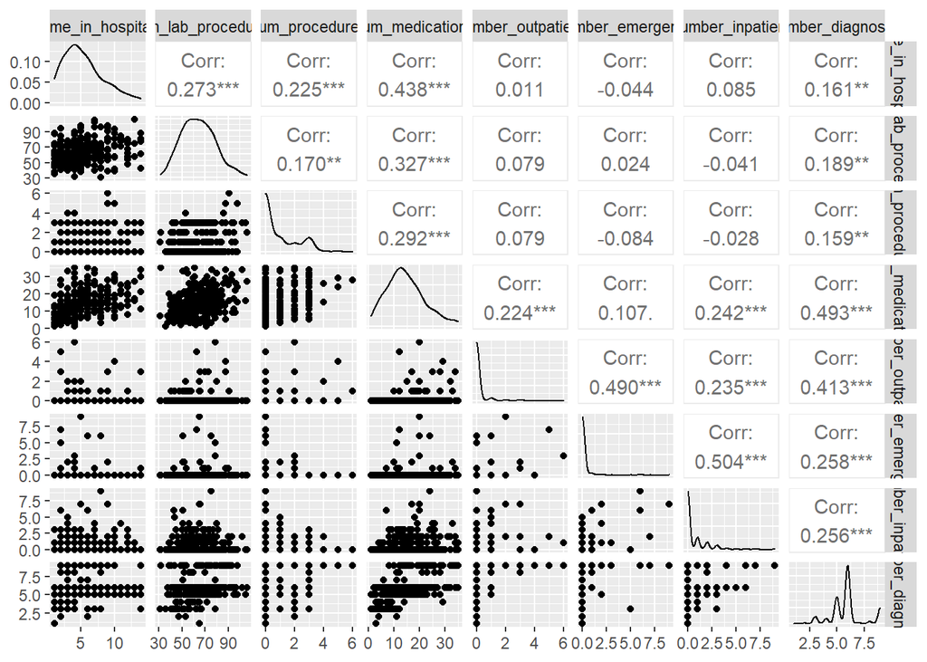

```r
ggpairs(readmission_num)
```

#Creating dummy variables

```r
#create dummy variables
library(caret)
d <- predict(dummyVars(~discharge_disposition_id + admission_type_id + max_glu_serum + A1Cresult + admission_source_id, data = readmission), newdata = readmission)
```

```r
#dataset of dummy variables
head(d)
```

```
##     discharge_disposition_id.1 discharge_disposition_id.2
## 163                          0                          0
## 193                          1                          0
## 461                          1                          0
## 594                          1                          0
## 697                          0                          0
## 772                          1                          0
##     discharge_disposition_id.3 discharge_disposition_id.5
## 163                          1                          0
## 193                          0                          0
## 461                          0                          0
## 594                          0                          0
## 697                          0                          0
## 772                          0                          0
##     discharge_disposition_id.6 discharge_disposition_id.7
```

[output cut: 48 more lines]

```r
#checking column names
colnames(d)
```

```
##  [1] "discharge_disposition_id.1"  "discharge_disposition_id.2"
##  [3] "discharge_disposition_id.3"  "discharge_disposition_id.5"
##  [5] "discharge_disposition_id.6"  "discharge_disposition_id.7"
##  [7] "discharge_disposition_id.10" "discharge_disposition_id.11"
##  [9] "discharge_disposition_id.13" "admission_type_id.1"
## [11] "admission_type_id.2"         "admission_type_id.3"
## [13] "admission_type_id.6"         "max_glu_serum.>200"
## [15] "max_glu_serum.>300"          "max_glu_serum.None"
## [17] "max_glu_serum.Norm"          "A1Cresult.>7"
## [19] "A1Cresult.>8"                "A1Cresult.None"
## [21] "A1Cresult.Norm"              "admission_source_id.1"
## [23] "admission_source_id.2"       "admission_source_id.7"
```

```r
#renaming column names
colnames(d)[colnames(d) == "max_glu_serum.>200"] <- "max_glu_serum.200"
colnames(d)[colnames(d) == "max_glu_serum.>300"] <- "max_glu_serum.300"
colnames(d)[colnames(d) == "A1Cresult.>7"] <- "A1Cresult7"
colnames(d)[colnames(d) == "A1Cresult.>8"] <- "A1Cresult8"
```

```r
colnames(d)
```

```
##  [1] "discharge_disposition_id.1"  "discharge_disposition_id.2"
##  [3] "discharge_disposition_id.3"  "discharge_disposition_id.5"
##  [5] "discharge_disposition_id.6"  "discharge_disposition_id.7"
##  [7] "discharge_disposition_id.10" "discharge_disposition_id.11"
##  [9] "discharge_disposition_id.13" "admission_type_id.1"
## [11] "admission_type_id.2"         "admission_type_id.3"
## [13] "admission_type_id.6"         "max_glu_serum.200"
## [15] "max_glu_serum.300"           "max_glu_serum.None"
## [17] "max_glu_serum.Norm"          "A1Cresult7"
## [19] "A1Cresult8"                  "A1Cresult.None"
## [21] "A1Cresult.Norm"              "admission_source_id.1"
## [23] "admission_source_id.2"       "admission_source_id.7"
```

##Creating diagnosis variables for diag_1, diag_2, diag_3

```r
myData_d<-readmission
```

```r
myData_d$diag_circ <- 0
myData_d$diag_resp <- 0
myData_d$diag_dig <- 0
myData_d$diag_diab <- 0
myData_d$diag_inj <- 0
myData_d$diag_musc <-0
myData_d$diag_geni <- 0
myData_d$diag_neop <-0
myData_d$diag_other <- 0
```

```r
#create diagnosis variable for circulatory codes:390-459, 785
myData_d$diag_circ[(as.character( myData_d$diag_1) >= "390" & as.character( myData_d$diag_1) <= "459" |  as.character( myData_d$diag_1 ) =="785")
                   | (as.character( myData_d$diag_2) >= "390" & as.character( myData_d$diag_2) <= "459" |  as.character( myData_d$diag_2 ) == "785")
                   | (as.character( myData_d$diag_3) >= "390" & as.character( myData_d$diag_3) <= "459" |  as.character( myData_d$diag_3 ) == "785")] <- 1
#create diagnosis variable for respiratory codes: 460-519, 786
myData_d$diag_resp[(as.character( myData_d$diag_1) >= "460" & as.character( myData_d$diag_1) <= "519" |  as.character( myData_d$diag_1 ) == "786")
                   | (as.character( myData_d$diag_2) >= "460" & as.character( myData_d$diag_2) <= "519" |  as.character( myData_d$diag_2 ) == "786")
                   | (as.character( myData_d$diag_3) >= "460" & as.character( myData_d$diag_3) <= "519" |  as.character( myData_d$diag_3 ) == "786")] <- 1
#create diagnosis variable for digestive codes: 520-579, 787
myData_d$diag_dig[(as.character( myData_d$diag_1) >= "520" & as.character( myData_d$diag_1) <= "579" |  as.character( myData_d$diag_1 ) == "787")
                  | (as.character( myData_d$diag_2) >= "520" & as.character( myData_d$diag_2) <= "579" |  as.character( myData_d$diag_2 ) == "787")
                  | (as.character( myData_d$diag_3) >= "520" & as.character( myData_d$diag_3) <= "579" |  as.character( myData_d$diag_3 ) == "787")] <- 1
#create diagnosis variable for diabetes mellitus codes: 250.xx
myData_d$diag_diab[(as.character(myData_d$diag_1) > "249" & as.character(myData_d$diag_1) < "251")
                   | (as.character(myData_d$diag_2) > "249" & as.character(myData_d$diag_2) < "251")
                   | (as.character(myData_d$diag_3) > "249" & as.character(myData_d$diag_3) < "251")] <- 1
#create diagnosis variable for injury codes: 800-999
myData_d$diag_inj[(as.character( myData_d$diag_1) >= "800" & as.character( myData_d$diag_1) <= "999")
                  | (as.character( myData_d$diag_2) >= "800" & as.character( myData_d$diag_2) <= "999")
                  | (as.character( myData_d$diag_3) >= "800" & as.character( myData_d$diag_3) <= "999")] <- 1
#create diagnosis variable for musculoskeletal codes: 710-739
myData_d$diag_musc[(as.character( myData_d$diag_1) >= "710" & as.character( myData_d$diag_1) <= "739")
                   | (as.character( myData_d$diag_2) >= "710" & as.character( myData_d$diag_2) <= "739")
                   | (as.character( myData_d$diag_3) >= "710" & as.character( myData_d$diag_3) <= "739")] <- 1
#create diagnosis variable for genitourinary codes: 580-629, 788
myData_d$diag_geni[(as.character( myData_d$diag_1) >= "580" & as.character( myData_d$diag_1) <= "629" |  as.character( myData_d$diag_1 ) == "788")
                   | (as.character( myData_d$diag_2) >= "580" & as.character( myData_d$diag_2) <= "629" |  as.character( myData_d$diag_2 ) == "788")
                   | (as.character( myData_d$diag_3) >= "580" & as.character( myData_d$diag_3) <= "629" |  as.character( myData_d$diag_3 ) == "788")] <- 1
#create diagnosis variable for neoplasms codes: 140-239
myData_d$diag_neop[(as.character( myData_d$diag_1) >= "140" & as.character( myData_d$diag_1) <= "239")
                   | (as.character( myData_d$diag_2) >= "140" & as.character( myData_d$diag_2) <= "239")
                   | (as.character( myData_d$diag_3) >= "140" & as.character( myData_d$diag_3) <= "239")] <- 1
#create diagnosis variable for other diseases
myData_d$diag_other[(as.character( myData_d$diag_1) == "780") | (as.character( myData_d$diag_1) == "781")
                    | (as.character( myData_d$diag_1) == "784") | (as.character( myData_d$diag_1) >= "790" & as.character( myData_d$diag_1) <= "799")
                    | (as.character( myData_d$diag_1) >= "240" & as.character( myData_d$diag_1) <= "249") | (as.character( myData_d$diag_1) >= "251" & as.character( myData_d$diag_1) <= "279")
                    | (as.character( myData_d$diag_1) >= "680" & as.character( myData_d$diag_1) <= "709") | (as.character( myData_d$diag_1) == "782")
                    | (as.character( myData_d$diag_1) >= "001" & as.character( myData_d$diag_1) <= "139") | (as.character( myData_d$diag_1) >= "290" & as.character( myData_d$diag_1) <= "319")
                    | (as.character( myData_d$diag_1) >= "280" & as.character( myData_d$diag_1) <= "289") | (as.character( myData_d$diag_1) >= "320" & as.character( myData_d$diag_1) <= "359")
                    | (as.character( myData_d$diag_1) >= "630" & as.character( myData_d$diag_1) <= "679") | (as.character( myData_d$diag_1) >= "360" & as.character( myData_d$diag_1) <= "389")
                    | (as.character( myData_d$diag_1) >= "740" & as.character( myData_d$diag_1) <= "759")
                    | (startsWith(as.character( myData_d$diag_1), 'E'))
                    | (startsWith(as.character( myData_d$diag_1), 'V'))
                    | (as.character( myData_d$diag_2) == "780") | (as.character( myData_d$diag_2) == "781")
                    | (as.character( myData_d$diag_2) == "784") | (as.character( myData_d$diag_2) >= "790" & as.character( myData_d$diag_2) <= "799")
                    | (as.character( myData_d$diag_2) >= "240" & as.character( myData_d$diag_2) <= "249") | (as.character( myData_d$diag_2) >= "251" & as.character( myData_d$diag_2) <= "279")
                    | (as.character( myData_d$diag_2) >= "680" & as.character( myData_d$diag_2) <= "709") | (as.character( myData_d$diag_2) == "782")
                    | (as.character( myData_d$diag_2) >= "001" & as.character( myData_d$diag_2) <= "139") | (as.character( myData_d$diag_2) >= "290" & as.character( myData_d$diag_2) <= "319")
                    | (as.character( myData_d$diag_2) >= "280" & as.character( myData_d$diag_2) <= "289") | (as.character( myData_d$diag_2) >= "320" & as.character( myData_d$diag_2) <= "359")
                    | (as.character( myData_d$diag_2) >= "630" & as.character( myData_d$diag_2) <= "679") | (as.character( myData_d$diag_2) >= "360" & as.character( myData_d$diag_2) <= "389")
                    | (as.character( myData_d$diag_2) >= "740" & as.character( myData_d$diag_2) <= "759")
                    | (startsWith(as.character( myData_d$diag_2), 'E'))
                    | (startsWith(as.character( myData_d$diag_2), 'V'))
                    | (as.character( myData_d$diag_3) == "780") | (as.character( myData_d$diag_3) == "781")
                    | (as.character( myData_d$diag_3) == "784") | (as.character( myData_d$diag_3) >= "790" & as.character( myData_d$diag_3) <= "799")
                    | (as.character( myData_d$diag_3) >= "240" & as.character( myData_d$diag_3) <= "249") | (as.character( myData_d$diag_3) >= "251" & as.character( myData_d$diag_3) <= "279")
                    | (as.character( myData_d$diag_3) >= "680" & as.character( myData_d$diag_3) <= "709") | (as.character( myData_d$diag_3) == "782")
                    | (as.character( myData_d$diag_3) >= "001" & as.character( myData_d$diag_3) <= "139") | (as.character( myData_d$diag_3) >= "290" & as.character( myData_d$diag_3) <= "319")
                    | (as.character( myData_d$diag_3) >= "280" & as.character( myData_d$diag_3) <= "289") | (as.character( myData_d$diag_3) >= "320" & as.character( myData_d$diag_3) <= "359")
                    | (as.character( myData_d$diag_3) >= "630" & as.character( myData_d$diag_3) <= "679") | (as.character( myData_d$diag_3) >= "360" & as.character( myData_d$diag_3) <= "389")
                    | (as.character( myData_d$diag_3) >= "740" & as.character( myData_d$diag_3) <= "759")
                    | (startsWith(as.character( myData_d$diag_3), 'E'))
                    | (startsWith(as.character( myData_d$diag_3), 'V'))] <- 1
```

```r
readmission <- myData_d
```

```r
head(readmission[, c(7:13, 17, 45:54)])
```

```
##     time_in_hospital num_lab_procedures num_procedures num_medications
## 163                5                 47              1               6
## 193                2                 53              0               4
## 461               10                 72              1              19
## 594                2                 61              0               5
## 697               11                 71              1              20
## 772               14                 43              0              11
##     number_outpatient number_emergency number_inpatient number_diagnoses
## 163                 0                0                0                5
## 193                 0                0                0                2
## 461                 0                0                0                5
## 594                 0                0                0                5
## 697                 0                0                0                5
## 772                 0                0                0                3
##     readmitted diag_circ diag_resp diag_dig diag_diab diag_inj diag_musc
## 163        YES         1         0        0         0        0         0
## 193        YES         1         0        0         1        0         0
## 461        YES         0         0        0         1        0         0
## 594         NO         0         0        0         1        0         0
## 697         NO         0         0        0         1        1         0
## 772        YES         0         0        1         1        0         0
##     diag_geni diag_neop diag_other
## 163         0         0          1
## 193         0         0          0
## 461         0         0          1
## 594         0         0          1
## 697         0         0          1
## 772         0         0          1
```

```r
readmission <- readmission[, c(7:13, 17, 45:54)]
```

```r
head(readmission)
```

```
##     time_in_hospital num_lab_procedures num_procedures num_medications
## 163                5                 47              1               6
## 193                2                 53              0               4
## 461               10                 72              1              19
## 594                2                 61              0               5
## 697               11                 71              1              20
## 772               14                 43              0              11
##     number_outpatient number_emergency number_inpatient number_diagnoses
## 163                 0                0                0                5
## 193                 0                0                0                2
## 461                 0                0                0                5
## 594                 0                0                0                5
## 697                 0                0                0                5
## 772                 0                0                0                3
##     readmitted diag_circ diag_resp diag_dig diag_diab diag_inj diag_musc
## 163        YES         1         0        0         0        0         0
## 193        YES         1         0        0         1        0         0
## 461        YES         0         0        0         1        0         0
## 594         NO         0         0        0         1        0         0
## 697         NO         0         0        0         1        1         0
## 772        YES         0         0        1         1        0         0
##     diag_geni diag_neop diag_other
## 163         0         0          1
## 193         0         0          0
## 461         0         0          1
## 594         0         0          1
## 697         0         0          1
## 772         0         0          1
```

```r
#combining dummy variables with numerical dataset
readmission<-cbind(readmission,d)
```

```r
head(readmission)
```

```
##     time_in_hospital num_lab_procedures num_procedures num_medications
## 163                5                 47              1               6
## 193                2                 53              0               4
## 461               10                 72              1              19
## 594                2                 61              0               5
## 697               11                 71              1              20
## 772               14                 43              0              11
##     number_outpatient number_emergency number_inpatient number_diagnoses
## 163                 0                0                0                5
## 193                 0                0                0                2
## 461                 0                0                0                5
## 594                 0                0                0                5
## 697                 0                0                0                5
## 772                 0                0                0                3
##     readmitted diag_circ diag_resp diag_dig diag_diab diag_inj diag_musc
```

[output cut: 69 more lines]

```r
nrow(readmission)
```

```
## [1] 298
```

```r
ncol(readmission)
```

```
## [1] 42
```

```r
#change outcome variable to factor
readmission$readmitted<-as.factor(readmission$readmitted)
```

```r
class(readmission$readmitted)
```

```
## [1] "factor"
```

```r
str(readmission)
```

```
## 'data.frame':    298 obs. of  42 variables:
##  $ time_in_hospital           : int  5 2 10 2 11 14 7 2 3 2 ...
##  $ num_lab_procedures         : int  47 53 72 61 71 43 105 66 76 43 ...
##  $ num_procedures             : int  1 0 1 0 1 0 3 0 0 0 ...
##  $ num_medications            : int  6 4 19 5 20 11 16 3 9 13 ...
##  $ number_outpatient          : int  0 0 0 0 0 0 0 0 0 0 ...
##  $ number_emergency           : int  0 0 0 0 0 0 0 0 0 0 ...
##  $ number_inpatient           : int  0 0 0 0 0 0 0 0 0 0 ...
##  $ number_diagnoses           : int  5 2 5 5 5 3 5 3 5 5 ...
##  $ readmitted                 : Factor w/ 2 levels "NO","YES": 2 2 2 1 1 2 2 2 2 2 ...
##  $ diag_circ                  : num  1 1 0 0 0 0 1 1 0 0 ...
##  $ diag_resp                  : num  0 0 0 0 0 0 0 0 0 0 ...
##  $ diag_dig                   : num  0 0 0 0 0 1 0 0 0 0 ...
##  $ diag_diab                  : num  0 1 1 1 1 1 1 1 0 1 ...
##  $ diag_inj                   : num  0 0 0 0 1 0 0 0 0 1 ...
```

[output cut: 28 more lines]

```r
#rearrange dataset to have outcome variable in last index position
readmission<-readmission[,c(1,2,3,4,5,6,7,8,10,11,12,13,14,15,16,17,18,19,20,21,22,23,24,25,26,27,28,29,30,31,32,33,34,35,36,37,38,39,40,41,42,9)]
```

```r
head(readmission)
```

```
##     time_in_hospital num_lab_procedures num_procedures num_medications
## 163                5                 47              1               6
## 193                2                 53              0               4
## 461               10                 72              1              19
## 594                2                 61              0               5
## 697               11                 71              1              20
## 772               14                 43              0              11
##     number_outpatient number_emergency number_inpatient number_diagnoses
## 163                 0                0                0                5
## 193                 0                0                0                2
## 461                 0                0                0                5
## 594                 0                0                0                5
## 697                 0                0                0                5
## 772                 0                0                0                3
##     diag_circ diag_resp diag_dig diag_diab diag_inj diag_musc diag_geni
```

[output cut: 69 more lines]

##Machine Learning-unsupervised learning

#k-means clustering

```r
#k-means clustering with numerical dataset
sapply(readmission_num,function(x)sum(is.na(x)))
```

```
##   time_in_hospital num_lab_procedures     num_procedures    num_medications
##                  0                  0                  0                  0
##  number_outpatient   number_emergency   number_inpatient   number_diagnoses
##                  0                  0                  0                  0
```

```r
wcss2 = vector()
for (i in 1:10){
    model = kmeans(readmission_num, i)
    wcss2[i] = sum(model$withinss)
}
```

```r
wcss = vector()
for (i in 1:10){
    print(i)
    model = kmeans(readmission_num, i)
    wcss[i] = sum(model$withinss)
    print(wcss[i])
}
```

```
## [1] 1
## [1] 82556.31
## [1] 2
## [1] 40235.37
## [1] 3
## [1] 29950.35
## [1] 4
## [1] 25279.98
## [1] 5
## [1] 20833.89
## [1] 6
## [1] 18132.46
## [1] 7
## [1] 16057.94
## [1] 8
## [1] 14766.3
## [1] 9
## [1] 13441.24
## [1] 10
## [1] 12586.56
```

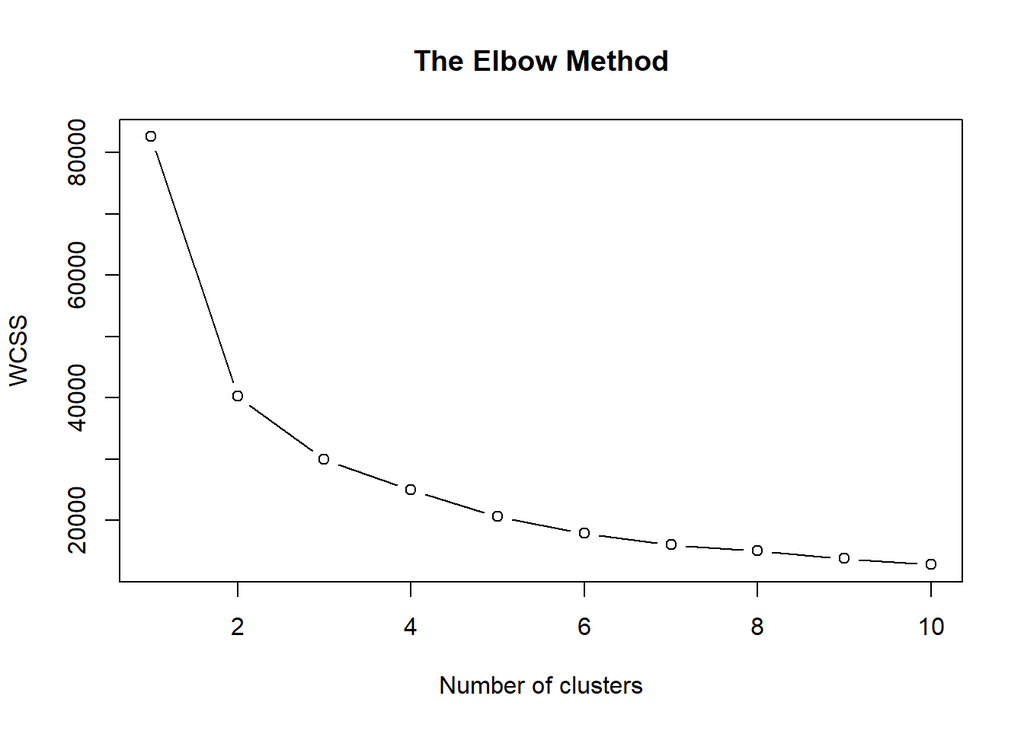

```r
wcss = vector()
for (i in 1:10){
    model = kmeans(readmission_num, i)
    wcss[i] = sum(model$withinss)
}

plot(1:10,
     wcss,
     type = 'b',
     main = paste('The Elbow Method'),
     xlab = 'Number of clusters',
     ylab = 'WCSS')
```

```r
kmeans = kmeans(x = readmission_num, centers = 3)
```

```r
kmeans$cluster
```

```
##    163    193    461    594    697    772    824    962   1281   1756   1984
##      3      3      1      1      1      3      2      1      1      3      3
##   2059   2080   2309   2484   3277   4104   4857   4967   5016   5149   5313
##      1      3      1      3      1      1      2      3      2      2      1
##   5388   5771   6129   6452   6953   7698   8270   8808   9119   9471   9689
##      1      1      3      3      1      2      1      2      2      2      2
##  10040  11728  11979  12275  12838  13235  13365  13549  13634  14644  15359
##      1      3      2      1      3      3      1      2      1      1      2
##  15538  15583  16431  16920  17097  17710  17795  17836  17839  18511  20963
##      2      3      2      2      2      1      1      3      3      3      2
##  22004  22438  23303  23465  23943  24103  24810  25851  25950  26277  26379
##      1      3      2      1      1      2      1      3      1      1      3
##  26453  26497  26826  26840  27472  27669  28370  28491  28772  28951  29058
##      3      1      1      3      2      1      1      2      2      2      3
##  29060  29127  29135  29181  29256  29366  29485  29487  29822  30613  30649
```

[output cut: 41 more lines]

```r
kmeans$centers
```

```
##   time_in_hospital num_lab_procedures num_procedures num_medications
## 1         5.225000           65.88333      0.7416667        15.14167
## 2         7.056338           83.63380      1.1830986        18.50704
## 3         4.542056           49.60748      0.7289720        11.14953
##   number_outpatient number_emergency number_inpatient number_diagnoses
## 1        0.15833333        0.1916667        0.7000000         5.908333
## 2        0.23943662        0.2253521        0.6056338         6.408451
## 3        0.09345794        0.1028037        0.6448598         5.588785
```

```r
wcss = kmeans$withinss
wcss
```

```
## [1] 11402.650  9428.056  9078.168
```

```r
sum(kmeans$withinss)
```

```
## [1] 29908.87
```

```r
kmeans$tot.withinss
```

```
## [1] 29908.87
```

```r
y_kmeans = kmeans$cluster
```

```r
# install.packages('cluster')
```

```r
library(cluster)
```

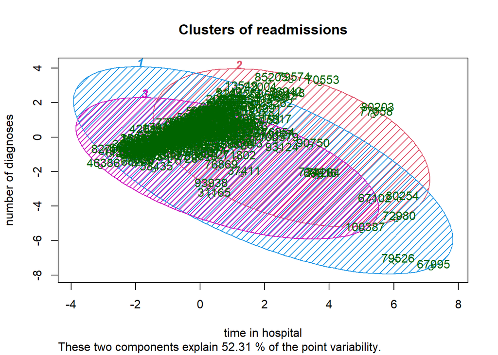

```r
clusplot(readmission_num,
         y_kmeans,
         lines = 0,
         shade = TRUE,
         color = TRUE,
         labels = 2,
         plotchar = FALSE,
         span = TRUE,
         main = 'Clusters of readmissions',
         xlab = 'time in hospital',
         ylab = 'number of diagnoses')
```

#principal component analysis(pca)

```r
# install.packages('caret')
# install.packages('e1071')
library(caret)
library(e1071)
readmission.pca <- prcomp(readmission_num, center = TRUE,scale. = TRUE)
```

```r
summary(readmission.pca)
```

```
## Importance of components:
##                           PC1    PC2    PC3    PC4     PC5    PC6     PC7
## Standard deviation     1.5785 1.3011 0.9455 0.9153 0.84398 0.7833 0.63138
## Proportion of Variance 0.3114 0.2116 0.1117 0.1047 0.08904 0.0767 0.04983
## Cumulative Proportion  0.3114 0.5231 0.6348 0.7395 0.82854 0.9052 0.95506
##                            PC8
## Standard deviation     0.59958
## Proportion of Variance 0.04494
## Cumulative Proportion  1.00000
```

```r
str(readmission.pca)
```

```
## List of 5
##  $ sdev    : num [1:8] 1.578 1.301 0.945 0.915 0.844 ...
##  $ rotation: num [1:8, 1:8] 0.277 0.252 0.207 0.469 0.39 ...
##   ..- attr(*, "dimnames")=List of 2
##   .. ..$ : chr [1:8] "time_in_hospital" "num_lab_procedures" "num_procedures" "num_medications" ...
##   .. ..$ : chr [1:8] "PC1" "PC2" "PC3" "PC4" ...
##  $ center  : Named num [1:8] 5.416 64.268 0.842 14.51 0.154 ...
##   ..- attr(*, "names")= chr [1:8] "time_in_hospital" "num_lab_procedures" "num_procedures" "num_medications" ...
##  $ scale   : Named num [1:8] 3.065 14.404 1.23 7.363 0.664 ...
##   ..- attr(*, "names")= chr [1:8] "time_in_hospital" "num_lab_procedures" "num_procedures" "num_medications" ...
##  $ x       : num [1:298, 1:8] -1.452 -2.805 0.266 -1.71 0.402 ...
##   ..- attr(*, "dimnames")=List of 2
##   .. ..$ : chr [1:298] "163" "193" "461" "594" ...
##   .. ..$ : chr [1:8] "PC1" "PC2" "PC3" "PC4" ...
##  - attr(*, "class")= chr "prcomp"
```

```r
library("factoextra")
get_eigenvalue(readmission.pca)
```

```
##       eigenvalue variance.percent cumulative.variance.percent
## Dim.1  2.4915339        31.144174                    31.14417
## Dim.2  1.6928847        21.161059                    52.30523
## Dim.3  0.8938827        11.173534                    63.47877
## Dim.4  0.8377119        10.471398                    73.95017
## Dim.5  0.7122940         8.903675                    82.85384
## Dim.6  0.6135632         7.669540                    90.52338
## Dim.7  0.3986345         4.982931                    95.50631
## Dim.8  0.3594952         4.493690                   100.00000
```

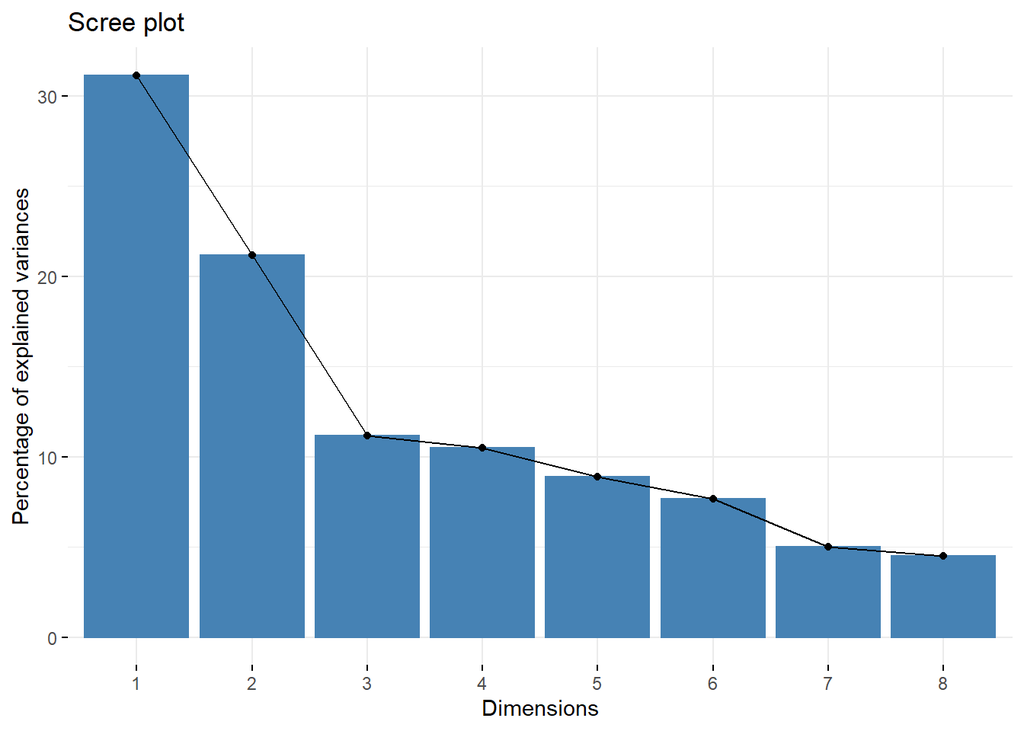

```r
#using variance:
library("factoextra")
fviz_eig(readmission.pca)
```

```r
# install.packages("remotes")
# remotes::install_github("vqv/ggbiplot")
```

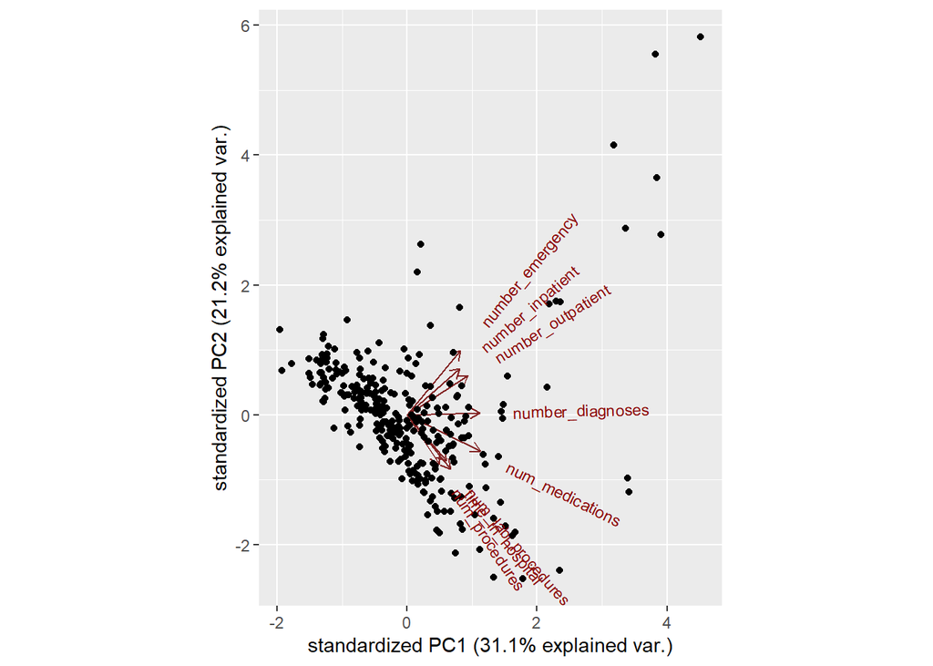

```r
library(ggbiplot)
ggbiplot(readmission.pca)
```

##Machine Learning-supervised learning

```r
#split data into train and test
library(caTools)
set.seed(123)
split = sample.split(readmission$readmitted, SplitRatio = 0.7)
training_set = subset(readmission, split == TRUE)
test_set = subset(readmission, split == FALSE)
```

#logistic regression

```r
#logistic regression
log.model.1 <- glm(formula=readmitted ~ . , family=binomial,data = training_set)
summary(log.model.1)
```

```
##
## Call:
## glm(formula = readmitted ~ ., family = binomial, data = training_set)
##
## Deviance Residuals:
##      Min        1Q    Median        3Q       Max
## -2.56398  -0.79188   0.09966   0.80780   1.92898
##
## Coefficients: (7 not defined because of singularities)
##                               Estimate Std. Error z value Pr(>|z|)
## (Intercept)                  3.572e+14  7.695e+14   0.464   0.6425
## time_in_hospital             1.077e-01  8.151e-02   1.321   0.1866
## num_lab_procedures          -1.267e-02  1.583e-02  -0.800   0.4234
## num_procedures              -3.895e-01  1.875e-01  -2.078   0.0377 *
## num_medications              7.196e-02  3.734e-02   1.927   0.0539 .
## number_outpatient            8.834e+00  4.492e+01   0.197   0.8441
## number_emergency             1.853e+01  2.471e+04   0.001   0.9994
## number_inpatient             5.851e-01  2.493e-01   2.347   0.0189 *
## number_diagnoses            -1.620e-01  2.040e-01  -0.794   0.4271
## diag_circ                   -5.670e-02  4.849e-01  -0.117   0.9069
## diag_resp                   -2.192e-01  4.844e-01  -0.453   0.6509
## diag_dig                    -1.048e-01  6.260e-01  -0.167   0.8671
## diag_diab                   -1.349e+00  4.686e-01  -2.878   0.0040 **
## diag_inj                    -5.186e-01  7.977e-01  -0.650   0.5156
## diag_musc                    4.775e-02  1.097e+00   0.044   0.9653
## diag_geni                   -4.430e-01  5.259e-01  -0.842   0.3996
## diag_neop                   -2.040e-01  1.077e+00  -0.189   0.8497
## diag_other                  -6.923e-01  4.708e-01  -1.470   0.1414
## discharge_disposition_id.1  -3.572e+14  7.695e+14  -0.464   0.6425
## discharge_disposition_id.2  -3.572e+14  7.695e+14  -0.464   0.6425
## discharge_disposition_id.3  -3.572e+14  7.695e+14  -0.464   0.6425
## discharge_disposition_id.5  -3.572e+14  7.695e+14  -0.464   0.6425
## discharge_disposition_id.6  -3.572e+14  7.695e+14  -0.464   0.6425
## discharge_disposition_id.7  -3.572e+14  7.695e+14  -0.464   0.6425
## discharge_disposition_id.10 -3.572e+14  7.695e+14  -0.464   0.6425
## discharge_disposition_id.11 -3.572e+14  7.695e+14  -0.464   0.6425
## discharge_disposition_id.13 -3.572e+14  7.695e+14  -0.464   0.6425
## admission_type_id.1          8.673e-01  8.333e-01   1.041   0.2980
## admission_type_id.2                 NA         NA      NA       NA
## admission_type_id.3         -5.956e-01  2.023e+00  -0.294   0.7685
## admission_type_id.6                 NA         NA      NA       NA
## max_glu_serum.200           -4.541e-01  5.020e-01  -0.905   0.3656
## max_glu_serum.300           -8.319e-01  5.688e-01  -1.463   0.1436
## max_glu_serum.None                  NA         NA      NA       NA
## max_glu_serum.Norm                  NA         NA      NA       NA
## A1Cresult7                   3.622e-01  5.835e-01   0.621   0.5348
## A1Cresult8                   1.203e+00  5.756e-01   2.090   0.0366 *
## A1Cresult.None                      NA         NA      NA       NA
## A1Cresult.Norm                      NA         NA      NA       NA
## admission_source_id.1        1.451e+00  7.244e-01   2.003   0.0452 *
## admission_source_id.2        2.625e+01  2.761e+05   0.000   0.9999
## admission_source_id.7               NA         NA      NA       NA
## ---
## Signif. codes:  0 '***' 0.001 '**' 0.01 '*' 0.05 '.' 0.1 ' ' 1
##
## (Dispersion parameter for binomial family taken to be 1)
##
##     Null deviance: 282.09  on 207  degrees of freedom
## Residual deviance: 197.64  on 173  degrees of freedom
## AIC: 267.64
##
## Number of Fisher Scoring iterations: 25
```

```r
#logistic regression
log.model.2 <- glm(formula=readmitted ~diag_diab+num_procedures+number_inpatient+A1Cresult8+admission_source_id.1 , family=binomial,data = training_set)
```

```r
summary(log.model.2)
```

```
##
## Call:
## glm(formula = readmitted ~ diag_diab + num_procedures + number_inpatient +
##     A1Cresult8 + admission_source_id.1, family = binomial, data = training_set)
##
## Deviance Residuals:
##     Min       1Q   Median       3Q      Max
## -2.4619  -1.1533   0.5639   1.0397   1.6613
##
## Coefficients:
##                       Estimate Std. Error z value Pr(>|z|)
## (Intercept)             0.3330     0.3168   1.051 0.293256
## diag_diab              -1.0559     0.3464  -3.048 0.002304 **
## num_procedures         -0.1224     0.1235  -0.991 0.321475
## number_inpatient        0.7595     0.2095   3.626 0.000288 ***
## A1Cresult8              0.6658     0.3296   2.020 0.043362 *
## admission_source_id.1   0.8427     0.5820   1.448 0.147633
## ---
## Signif. codes:  0 '***' 0.001 '**' 0.01 '*' 0.05 '.' 0.1 ' ' 1
##
## (Dispersion parameter for binomial family taken to be 1)
##
##     Null deviance: 282.09  on 207  degrees of freedom
## Residual deviance: 251.32  on 202  degrees of freedom
## AIC: 263.32
##
## Number of Fisher Scoring iterations: 4
```

```r
#variable importance for logistic regression
library(caret)
importance<-varImp(log.model.1, scale=FALSE)
importance
```

```
##                                  Overall
## time_in_hospital            1.320790e+00
## num_lab_procedures          8.004702e-01
## num_procedures              2.077970e+00
## num_medications             1.927253e+00
## number_outpatient           1.966796e-01
## number_emergency            7.500721e-04
## number_inpatient            2.346880e+00
## number_diagnoses            7.941885e-01
## diag_circ                   1.169293e-01
## diag_resp                   4.525598e-01
## diag_dig                    1.673991e-01
## diag_diab                   2.878115e+00
## diag_inj                    6.501004e-01
## diag_musc                   4.352293e-02
## diag_geni                   8.423237e-01
## diag_neop                   1.894732e-01
## diag_other                  1.470424e+00
## discharge_disposition_id.1  4.642062e-01
## discharge_disposition_id.2  4.642062e-01
## discharge_disposition_id.3  4.642062e-01
## discharge_disposition_id.5  4.642062e-01
## discharge_disposition_id.6  4.642062e-01
## discharge_disposition_id.7  4.642062e-01
## discharge_disposition_id.10 4.642062e-01
## discharge_disposition_id.11 4.642062e-01
## discharge_disposition_id.13 4.642062e-01
## admission_type_id.1         1.040837e+00
## admission_type_id.3         2.943619e-01
## max_glu_serum.200           9.047262e-01
## max_glu_serum.300           1.462655e+00
## A1Cresult7                  6.206708e-01
## A1Cresult8                  2.090126e+00
## admission_source_id.1       2.002637e+00
## admission_source_id.2       9.508525e-05
```

```r
#count number of NA's in test data
sum(is.na(test_set))
```

```
## [1] 0
```

```r
results = predict(log.model.2, test_set, type='response')
results
```

```
##       193       772       824      1756      2080      3277      4967      5313
## 0.4857321 0.3267494 0.2515713 0.3267494 0.3267494 0.3267494 0.5824830 0.4857321
##      5771      6129      6452      7698      9119      9689     11728     13549
## 0.4857321 0.8369788 0.5824830 0.7308248 0.4857321 0.8118400 0.8257387 0.2515713
##     13634     15359     15538     17097     17710     17836     20963     23465
## 0.4250758 0.7308248 0.4857321 0.4857321 0.7308248 0.5091552 0.3267494 0.4552379
##     26840     29135     29256     29485     31165     31275     33020     34606
## 0.5824830 0.3004059 0.5524396 0.3954614 0.9788424 0.2515713 0.9483451 0.7060693
##     35443     35975     36685     36745     37402     37411     37656     39068
## 0.9517133 0.4857321 0.3267494 0.3267494 0.4914131 0.9821594 0.5824830 0.8369788
##     39356     39784     41134     42011     42257     43185     44171     44259
## 0.7308248 0.3267494 0.4857321 0.4250758 0.9498761 0.9316058 0.8152885 0.3954614
##     53376     53547     56068     57291     57410     57806     63412     65813
## 0.3954614 0.6687334 0.8242161 0.8007574 0.4857321 0.4552379 0.6737506 0.5824830
##     66118     66258     67316     67406     67529     67995     68427     69010
## 0.4857321 0.8493652 0.4857321 0.5091552 0.3004059 0.9948303 0.4857321 0.4857321
##     69118     70175     70357     71151     71802     71940     72980     74284
## 0.4857321 0.4857321 0.9636473 0.3267494 0.9092677 0.4857321 0.9988637 0.9457650
##     74286     74831     74933     77281     77674     80203     80411     80568
## 0.2753177 0.5824830 0.4857321 0.6868919 0.6868919 0.3386545 0.7308248 0.4552379
##     80810     81744     85158     92591     97084     98208     99005    100387
## 0.9021689 0.7488566 0.7308248 0.7308248 0.6800339 0.3954614 0.4857321 0.9983392
##    100494    100579
## 0.4857321 0.9253878
```

```r
results_class <- ifelse(results>0.5, 1,0)
results_class
```

```
##    193    772    824   1756   2080   3277   4967   5313   5771   6129   6452
##      0      0      0      0      0      0      1      0      0      1      1
##   7698   9119   9689  11728  13549  13634  15359  15538  17097  17710  17836
##      1      0      1      1      0      0      1      0      0      1      1
##  20963  23465  26840  29135  29256  29485  31165  31275  33020  34606  35443
##      0      0      1      0      1      0      1      0      1      1      1
##  35975  36685  36745  37402  37411  37656  39068  39356  39784  41134  42011
##      0      0      0      0      1      1      1      1      0      0      0
##  42257  43185  44171  44259  53376  53547  56068  57291  57410  57806  63412
##      1      1      1      0      0      1      1      1      0      0      1
##  65813  66118  66258  67316  67406  67529  67995  68427  69010  69118  70175
##      1      0      1      0      1      0      1      0      0      0      0
##  70357  71151  71802  71940  72980  74284  74286  74831  74933  77281  77674
##      1      0      1      0      1      1      0      1      0      1      1
##  80203  80411  80568  80810  81744  85158  92591  97084  98208  99005 100387
##      0      1      0      1      1      1      1      1      0      0      1
## 100494 100579
##      0      1
```

```r
table(test_set$readmitted, results_class)
```

```
##      results_class
##        0  1
##   NO  22 15
##   YES 23 30
```

```r
misClasificError <- mean(results_class != test_set$readmitted)
print(paste('Accuracy',1-misClasificError))
```

```
## [1] "Accuracy 0"
```

```r
#sensitivity=TP/TP+FN
sensitivity=30/(30+23)
sensitivity
```

```
## [1] 0.5660377
```

```r
#spec=TN/TN+FP
spec=22/(22+15)
spec
```

```
## [1] 0.5945946
```

```r
library(pROC)
```

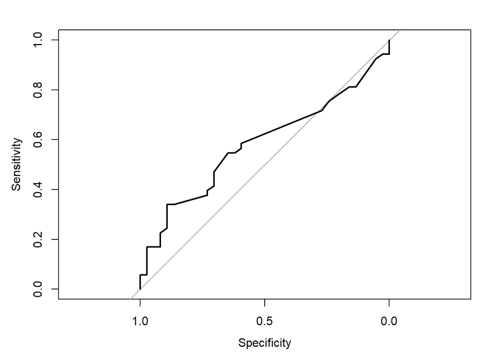

```
##
## Call:
## roc.default(response = test_set$readmitted, predictor = results,     plot = TRUE)
##
## Data: results in 37 controls (test_set$readmitted NO) < 53 cases (test_set$readmitted YES).
## Area under the curve: 0.5806
```

```r
roc(test_set$readmitted, results, plot=TRUE,)
```

```r
auc(test_set$readmitted, results)
```

```
## Area under the curve: 0.5806
```

#random forest

```r
#random forest
#install.packages('randomForest')
library(randomForest)
RF <- randomForest(formula = readmitted ~ ., method='class',
                 data = training_set)
print(RF)
```

```
##
## Call:
##  randomForest(formula = readmitted ~ ., data = training_set, method = "class")
##                Type of random forest: classification
##                      Number of trees: 500
## No. of variables tried at each split: 6
##
##         OOB estimate of  error rate: 33.17%
## Confusion matrix:
##     NO YES class.error
## NO  41  45   0.5232558
## YES 24  98   0.1967213
```

```r
importance(RF)
```

```
##                             MeanDecreaseGini
## time_in_hospital                  9.62302545
## num_lab_procedures               11.66886291
## num_procedures                    4.05618872
## num_medications                  14.45370055
## number_outpatient                 1.65705815
## number_emergency                  0.80206313
## number_inpatient                  6.49082543
## number_diagnoses                  3.87331002
## diag_circ                         2.23960273
## diag_resp                         1.97203917
## diag_dig                          1.21341603
## diag_diab                         3.47971852
## diag_inj                          1.41396042
## diag_musc                         0.60591823
## diag_geni                         1.86579845
## diag_neop                         0.72582356
## diag_other                        2.30133405
## discharge_disposition_id.1        2.46515914
## discharge_disposition_id.2        1.52314551
## discharge_disposition_id.3        1.53324837
## discharge_disposition_id.5        0.50742156
## discharge_disposition_id.6        1.02429830
## discharge_disposition_id.7        0.35408930
## discharge_disposition_id.10       0.09673161
## discharge_disposition_id.11       0.54837214
## discharge_disposition_id.13       0.16244344
## admission_type_id.1               0.91419015
## admission_type_id.2               0.00000000
## admission_type_id.3               0.13510266
## admission_type_id.6               0.96136526
## max_glu_serum.200                 1.71309899
## max_glu_serum.300                 1.67244094
## max_glu_serum.None                0.00000000
## max_glu_serum.Norm                1.85534410
## A1Cresult7                        1.53953307
## A1Cresult8                        1.94166881
## A1Cresult.None                    0.00000000
## A1Cresult.Norm                    1.77953374
## admission_source_id.1             1.49926541
## admission_source_id.2             0.12604626
## admission_source_id.7             1.64039726
```

```r
#MeanDecreaseGin --> Importance (IncNodePurity)
test_set[-42]
```

[output not shown]

[output cut: 1168 more lines]

```r
# Predicting the Test set results
y_pred = predict(RF, newdata = test_set)
```

```r
confusionMatrix(test_set[, 42], y_pred)
```

```
## Confusion Matrix and Statistics
##
##           Reference
## Prediction NO YES
##        NO  14  23
##        YES 18  35
##
##                Accuracy : 0.5444
##                  95% CI : (0.436, 0.6498)
##     No Information Rate : 0.6444
##     P-Value [Acc > NIR] : 0.9805
##
##                   Kappa : 0.0396
##
##  Mcnemar's Test P-Value : 0.5322
##
##             Sensitivity : 0.4375
##             Specificity : 0.6034
##          Pos Pred Value : 0.3784
##          Neg Pred Value : 0.6604
##              Prevalence : 0.3556
##          Detection Rate : 0.1556
##    Detection Prevalence : 0.4111
##       Balanced Accuracy : 0.5205
##
##        'Positive' Class : NO
##
```

#Xgboost

```r
#Xgboost
# install.packages('xgboost')
library(xgboost)
classifier = xgboost(data = as.matrix(training_set[-42]), label = training_set$readmitted, nrounds = 10)
y_pred = predict(classifier, newdata = as.matrix(test_set[-42]))
```

```r
head(y_pred)
```

```
## [1] 1.1965128 1.6972945 0.6581497 1.3713812 1.4290059 1.0798059
```

```r
y_pred = (y_pred >= 0.5)
```

```r
head(y_pred)
```

```
## [1] TRUE TRUE TRUE TRUE TRUE TRUE
```

```r
cm = table(test_set[, 42], y_pred)
cm
```

```
##      y_pred
##       TRUE
##   NO    37
##   YES   53
```

```r
imp_matrix = xgb.importance(model=classifier)
imp_matrix
```

```
##                         Feature         Gain       Cover   Frequency
##  1:             num_medications 0.2372067682 0.147784101 0.137931034
##  2:          num_lab_procedures 0.2313646203 0.179427487 0.232758621
##  3:            time_in_hospital 0.1604333697 0.125538886 0.219827586
##  4:            number_inpatient 0.0580954063 0.067511640 0.047413793
##  5:              num_procedures 0.0350209748 0.031212278 0.038793103
##  6:                   diag_diab 0.0278827499 0.057509916 0.021551724
##  7:                    diag_inj 0.0259696330 0.022331436 0.021551724
##  8:            number_diagnoses 0.0247044286 0.040093120 0.030172414
##  9:                   diag_circ 0.0218722794 0.007242628 0.021551724
## 10:              A1Cresult.Norm 0.0208096595 0.010432833 0.004310345
## 11:  discharge_disposition_id.5 0.0175217089 0.021469219 0.017241379
## 12:                   diag_geni 0.0161828814 0.011208829 0.017241379
## 13:  discharge_disposition_id.6 0.0142663160 0.019313675 0.017241379
## 14:           max_glu_serum.200 0.0135488177 0.009743059 0.017241379
```

[output cut: 16 more lines]

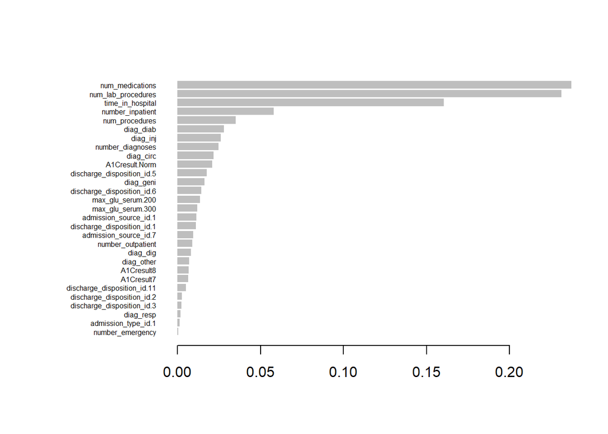

```r
xgb.plot.importance(imp_matrix)
```

```r
folds = createFolds(training_set$readmitted, k = 10)
class(folds)
```

```
## [1] "list"
```

```r
cv = lapply(folds, function(x) {
  training_fold = training_set[-x, ]
  test_fold = training_set[x, ]
  classifier = xgboost(data = as.matrix(training_fold[-42]), label = training_fold$readmitted, nrounds = 10)
  y_pred = predict(classifier, newdata = as.matrix(test_fold[-42]))
  y_pred = (y_pred >= 0.5)
  cm = table(test_fold[, 42], y_pred)
  accuracy = (cm[2,1]) / (cm[1,1] + cm[2,1])
  return(accuracy)
})
accuracy = mean(as.numeric(cv))
accuracy
```

```
## [1] 0.5867532
```

```r
cv
```

```
## $Fold01
## [1] 0.5909091
##
## $Fold02
## [1] 0.5714286
##
## $Fold03
## [1] 0.5714286
##
## $Fold04
## [1] 0.5714286
##
## $Fold05
## [1] 0.6
##
## $Fold06
## [1] 0.5714286
##
## $Fold07
## [1] 0.6
##
## $Fold08
## [1] 0.5909091
##
## $Fold09
## [1] 0.6
##
## $Fold10
## [1] 0.6
```

```r
#feature scaling
library(caret)
normParam <- preProcess(training_set, method = c("center", "scale"))
training_set <- predict(normParam, training_set)
test_set <- predict(normParam, test_set)
```

#KNN

```r
#KNN
library(class)
y_pred = knn(train = training_set[, -42],
             test = test_set[, -42],
             cl = training_set[, 42],
             k = 5)

y_pred
```

```
##  [1] NO  NO  NO  NO  NO  NO  NO  NO  NO  YES YES YES NO  YES NO  NO  YES YES YES
## [20] YES YES NO  NO  YES YES YES NO  NO  YES NO  YES YES YES YES NO  NO  NO  YES
## [39] YES YES NO  NO  YES NO  YES YES YES YES NO  NO  YES YES NO  NO  YES YES NO
## [58] NO  NO  YES YES YES YES NO  NO  NO  NO  NO  YES YES YES YES YES NO  NO  YES
## [77] YES YES YES YES NO  YES YES YES NO  NO  YES YES NO  YES
## Levels: NO YES
```

```r
# Fitting KNN to the Training set and Predicting the Test set results
library(class)
vec = c()
k_vec = c()
for (k in 1:50){
y_pred = knn(train = training_set[, -42],
             test = test_set[, -42],
             cl = training_set[, 42],
             k = 8)
y_pred

error = mean(y_pred != test_set$readmitted)
k_vec = c(k_vec, k)
vec = c(vec, error)}
```

```r
vec
```

```
##  [1] 0.5000000 0.4666667 0.5222222 0.4666667 0.4666667 0.5000000 0.4888889
##  [8] 0.4555556 0.4888889 0.4666667 0.4666667 0.4888889 0.5000000 0.4666667
## [15] 0.4555556 0.5222222 0.4888889 0.5111111 0.5222222 0.5000000 0.5000000
## [22] 0.4444444 0.4666667 0.4444444 0.4888889 0.4888889 0.5000000 0.4444444
## [29] 0.4888889 0.5333333 0.5111111 0.4555556 0.4777778 0.4666667 0.5000000
## [36] 0.4666667 0.4555556 0.4888889 0.4555556 0.5000000 0.5000000 0.5111111
## [43] 0.4444444 0.5000000 0.4666667 0.5111111 0.4555556 0.4777778 0.5333333
## [50] 0.4888889
```

```r
df.error = data.frame(k_vec,vec)
df.error
```

```
##    k_vec       vec
## 1      1 0.5000000
## 2      2 0.4666667
## 3      3 0.5222222
## 4      4 0.4666667
## 5      5 0.4666667
## 6      6 0.5000000
## 7      7 0.4888889
## 8      8 0.4555556
## 9      9 0.4888889
## 10    10 0.4666667
## 11    11 0.4666667
## 12    12 0.4888889
## 13    13 0.5000000
## 14    14 0.4666667
```

[output cut: 36 more lines]

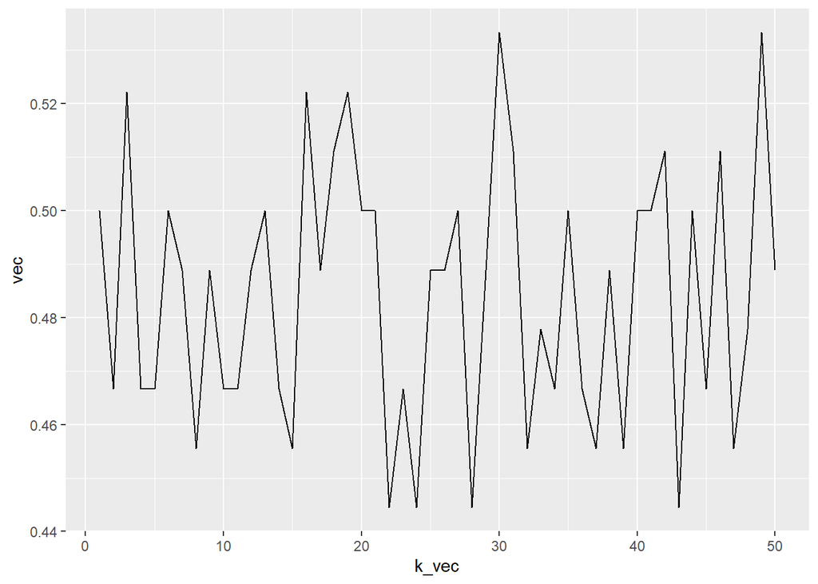

```r
ggplot(df.error, aes(k_vec, vec))+geom_line()
```

```r
y_pred = knn(train = training_set[, -42],
             test = test_set[, -42],
             cl = training_set[, 42],
             k = 18)
y_pred
```

```
##  [1] NO  YES NO  NO  NO  NO  NO  NO  NO  YES YES YES NO  YES NO  NO  YES YES NO
## [20] NO  YES NO  NO  NO  YES YES NO  YES YES NO  YES YES YES NO  NO  NO  NO  YES
## [39] YES YES NO  NO  NO  NO  YES YES YES NO  NO  NO  YES YES NO  NO  YES YES NO
## [58] NO  NO  YES YES YES YES NO  NO  NO  YES NO  YES NO  YES YES YES NO  NO  YES
## [77] NO  YES YES NO  YES YES NO  YES NO  NO  NO  YES YES YES
## Levels: NO YES
```

```r
# Making the Confusion Matrix
cm = table(test_set[, 42], y_pred)
cm
```

```
##      y_pred
##       NO YES
##   NO  20  17
##   YES 27  26
```

```r
confusionMatrix(test_set[, 42], y_pred)
```

```
## Confusion Matrix and Statistics
##
##           Reference
## Prediction NO YES
##        NO  20  17
##        YES 27  26
##
##                Accuracy : 0.5111
##                  95% CI : (0.4035, 0.618)
##     No Information Rate : 0.5222
##     P-Value [Acc > NIR] : 0.6246
##
##                   Kappa : 0.0299
##
##  Mcnemar's Test P-Value : 0.1748
##
##             Sensitivity : 0.4255
##             Specificity : 0.6047
##          Pos Pred Value : 0.5405
##          Neg Pred Value : 0.4906
##              Prevalence : 0.5222
##          Detection Rate : 0.2222
##    Detection Prevalence : 0.4111
##       Balanced Accuracy : 0.5151
##
##        'Positive' Class : NO
##
```

#SVM

```r
# Fitting SVM to the Training set
library(e1071)
classifier = svm(formula = readmitted ~ .,
                 data = training_set,
                 kernel = 'linear')
# Predicting the Test set results
y_pred = predict(classifier, newdata = test_set[-42])
print(y_pred)
```

```
##    193    772    824   1756   2080   3277   4967   5313   5771   6129   6452
##     NO    YES     NO     NO     NO     NO    YES    YES     NO    YES    YES
##   7698   9119   9689  11728  13549  13634  15359  15538  17097  17710  17836
##    YES     NO    YES    YES    YES    YES     NO    YES    YES    YES     NO
##  20963  23465  26840  29135  29256  29485  31165  31275  33020  34606  35443
##     NO     NO     NO     NO     NO    YES    YES     NO    YES    YES    YES
##  35975  36685  36745  37402  37411  37656  39068  39356  39784  41134  42011
##     NO     NO     NO     NO    YES    YES    YES    YES     NO     NO    YES
##  42257  43185  44171  44259  53376  53547  56068  57291  57410  57806  63412
##    YES    YES    YES     NO     NO    YES    YES    YES     NO     NO    YES
##  65813  66118  66258  67316  67406  67529  67995  68427  69010  69118  70175
##    YES    YES    YES     NO     NO    YES    YES    YES     NO     NO     NO
##  70357  71151  71802  71940  72980  74284  74286  74831  74933  77281  77674
##    YES     NO    YES    YES    YES    YES     NO    YES     NO    YES    YES
##  80203  80411  80568  80810  81744  85158  92591  97084  98208  99005 100387
##     NO    YES    YES    YES    YES    YES    YES     NO     NO     NO    YES
## 100494 100579
##     NO    YES
## Levels: NO YES
```

```r
# Making the Confusion Matrix
cm = table(test_set[, 42], y_pred)
cm
```

```
##      y_pred
##       NO YES
##   NO  19  18
##   YES 19  34
```

```r
confusionMatrix(test_set[, 42], y_pred)
```

```
## Confusion Matrix and Statistics
##
##           Reference
## Prediction NO YES
##        NO  19  18
##        YES 19  34
##
##                Accuracy : 0.5889
##                  95% CI : (0.4802, 0.6916)
##     No Information Rate : 0.5778
##     P-Value [Acc > NIR] : 0.4597
##
##                   Kappa : 0.1544
##
##  Mcnemar's Test P-Value : 1.0000
##
##             Sensitivity : 0.5000
##             Specificity : 0.6538
##          Pos Pred Value : 0.5135
##          Neg Pred Value : 0.6415
##              Prevalence : 0.4222
##          Detection Rate : 0.2111
##    Detection Prevalence : 0.4111
##       Balanced Accuracy : 0.5769
##
##        'Positive' Class : NO
##
```

```r
# Fitting SVM to the Training set with radial kernel
#install.packages('e1071')
library(e1071)
classifier = svm(formula = readmitted ~ .,
                 data = training_set,
                 kernel = 'radial')
# Predicting the Test set results
y_pred = predict(classifier, newdata = test_set[-42])
#
# # Making the Confusion Matrix
cm = table(test_set[, 42], y_pred)
summary(classifier)
```

```
##
## Call:
## svm(formula = readmitted ~ ., data = training_set, kernel = "radial")
##
##
## Parameters:
##    SVM-Type:  C-classification
##  SVM-Kernel:  radial
##        cost:  1
##
## Number of Support Vectors:  176
##
##  ( 97 79 )
##
##
## Number of Classes:  2
##
## Levels:
##  NO YES
```

```r
confusionMatrix(test_set[, 42], y_pred)
```

```
## Confusion Matrix and Statistics
##
##           Reference
## Prediction NO YES
##        NO  17  20
##        YES 12  41
##
##                Accuracy : 0.6444
##                  95% CI : (0.5365, 0.7426)
##     No Information Rate : 0.6778
##     P-Value [Acc > NIR] : 0.7865
##
##                   Kappa : 0.2409
##
##  Mcnemar's Test P-Value : 0.2159
##
##             Sensitivity : 0.5862
##             Specificity : 0.6721
##          Pos Pred Value : 0.4595
##          Neg Pred Value : 0.7736
##              Prevalence : 0.3222
##          Detection Rate : 0.1889
##    Detection Prevalence : 0.4111
##       Balanced Accuracy : 0.6292
##
##        'Positive' Class : NO
##
```

```r
summary(classifier)
```

```
##
## Call:
## svm(formula = readmitted ~ ., data = training_set, kernel = "radial")
##
##
## Parameters:
##    SVM-Type:  C-classification
##  SVM-Kernel:  radial
##        cost:  1
##
## Number of Support Vectors:  176
##
##  ( 97 79 )
##
##
## Number of Classes:  2
##
## Levels:
##  NO YES
```

```r
#tuning
tune.results <- tune(svm,train.x=training_set[,-42],train.y=training_set[,42],kernel='radial',
                  ranges=list(cost=10^(-1:2), gamma=c(0.25,.5,1,2)))
summary(tune.results)
```

```
##
## Parameter tuning of 'svm':
##
## - sampling method: 10-fold cross validation
##
## - best parameters:
##  cost gamma
##    10  0.25
##
## - best performance: 0.365
##
## - Detailed performance results:
##     cost gamma     error dispersion
## 1    0.1  0.25 0.4121429  0.1394318
## 2    1.0  0.25 0.3935714  0.1162207
## 3   10.0  0.25 0.3650000  0.1135672
## 4  100.0  0.25 0.3650000  0.1135672
## 5    0.1  0.50 0.4121429  0.1394318
## 6    1.0  0.50 0.4171429  0.1259922
## 7   10.0  0.50 0.4126190  0.1186663
## 8  100.0  0.50 0.4126190  0.1186663
## 9    0.1  1.00 0.4121429  0.1394318
## 10   1.0  1.00 0.4073810  0.1378051
## 11  10.0  1.00 0.4073810  0.1378051
## 12 100.0  1.00 0.4073810  0.1378051
## 13   0.1  2.00 0.4121429  0.1394318
## 14   1.0  2.00 0.3978571  0.1281615
## 15  10.0  2.00 0.3978571  0.1281615
## 16 100.0  2.00 0.3978571  0.1281615
```

```r
classifier = svm(formula = readmitted ~ .,
                 data = training_set,
                 type = 'C-classification',
                 kernel = 'radial',
                 cost=10,
                 gamma=0.25)
#Predicting the Test set results
y_pred = predict(classifier, newdata = test_set[-42])

#Making the Confusion Matrix
cm = table(test_set[, 42], y_pred)
cm
```

```
##      y_pred
##       NO YES
##   NO   7  30
##   YES 10  43
```

```r
confusionMatrix(test_set[, 42], y_pred)
```

```
## Confusion Matrix and Statistics
##
##           Reference
## Prediction NO YES
##        NO   7  30
##        YES 10  43
##
##                Accuracy : 0.5556
##                  95% CI : (0.447, 0.6604)
##     No Information Rate : 0.8111
##     P-Value [Acc > NIR] : 1.000000
##
##                   Kappa : 6e-04
##
##  Mcnemar's Test P-Value : 0.002663
##
##             Sensitivity : 0.41176
##             Specificity : 0.58904
##          Pos Pred Value : 0.18919
##          Neg Pred Value : 0.81132
##              Prevalence : 0.18889
##          Detection Rate : 0.07778
##    Detection Prevalence : 0.41111
##       Balanced Accuracy : 0.50040
##
##        'Positive' Class : NO
##
```

```r
summary(classifier)
```

```
##
## Call:
## svm(formula = readmitted ~ ., data = training_set, type = "C-classification",
##     kernel = "radial", cost = 10, gamma = 0.25)
##
##
## Parameters:
##    SVM-Type:  C-classification
##  SVM-Kernel:  radial
##        cost:  10
##
## Number of Support Vectors:  203
##
##  ( 121 82 )
##
##
## Number of Classes:  2
##
## Levels:
##  NO YES
```

#Assessing the models-cross validation

```r
#cross-validation
train_control <- trainControl(method = "cv",
                              number = 5,
                              classProbs = TRUE,
                              summaryFunction=twoClassSummary)
model <- train(readmitted ~., data = readmission,
               method = "rf",
               metric="ROC",
               trControl = train_control)
```

```r
print(model)
```

```
## Random Forest
##
## 298 samples
##  41 predictor
##   2 classes: 'NO', 'YES'
##
## No pre-processing
## Resampling: Cross-Validated (5 fold)
## Summary of sample sizes: 239, 238, 239, 238, 238
## Resampling results across tuning parameters:
##
##   mtry  ROC        Sens       Spec
##    2    0.6714905  0.2763333  0.8228571
##   21    0.6418476  0.4223333  0.6971429
##   41    0.6524381  0.4710000  0.7257143
##
## ROC was used to select the optimal model using the largest value.
## The final value used for the model was mtry = 2.
```

```r
# install.packages('kernlab')
```

```r
train_control <- trainControl(method = "cv",
                              number = 5,
                              classProbs = TRUE,
                              summaryFunction=twoClassSummary)
model <- train(readmitted ~., data = readmission,
               method = "svmLinear",
               metric="ROC",
               trControl = train_control)
print(model)
```

```
## Support Vector Machines with Linear Kernel
##
## 298 samples
##  41 predictor
##   2 classes: 'NO', 'YES'
##
## No pre-processing
## Resampling: Cross-Validated (5 fold)
## Summary of sample sizes: 238, 238, 239, 239, 238
## Resampling results:
##
##   ROC        Sens   Spec
##   0.6967429  0.357  0.8514286
##
## Tuning parameter 'C' was held constant at a value of 1
```

##Conclusion

The dataset had 101766 rows and 50 columns.I decided to remove the columns “encounter_id”, “patient_nbr” because they are not important, and “weight”, “payer_code”, and “medical_specialty” since they had a lot of missing values.I also removed the rows with “None” value in the features “max_glu_serum” and “A1Cresult” as it would not provide useful information.I was left with 298 rows and 45 columns after cleaning.

After that, I classified the outcome variable into 2 groups:“YES” and “NO” using a criteria that would be more balanced.It would be difficult to encode dummy variables for “diag_1”, “diag_2”, and “diag_3” since they have a lot of levels, so I created diagnosis variables with ICD-9 codes.The ML models included k-means clustering, PCA,logistic regression, random forest,Xgboost, KNN, SVM,and cross-validation, using performance metrics such as accuracy, sensitivity,specificity, AUC, and AIC. From my analysis, the winning model is SVM with the highest accuracy of 0.64.